# GPFR example

Suppose we have a functional response variable $y_m(t), \ m=1,\dots,M$, a functional covariate $x_m(t)$ and also a set of $p=2$ scalar covariates $\textbf{u}_m = (u_{m0},u_{m1})^\top$.

A Gaussian process functional regression (GPFR) model used in this example is defined by

$y_m(t) = \mu_m(t) + \tau_m(x_m(t)) + \varepsilon_m(t)$,

where $\mu_m(t) = \textbf{u}_m^\top \boldsymbol{\beta}(t)$ is the mean function model across different curves and $\tau_m(x_m(t))$ is a Gaussian process with zero mean and covariance function $k_m(\boldsymbol{\theta}|x_m(t))$. That is, $\tau_m(x_m(t))$ defines the covariance structure of $y_m(t)$ for the different data points within the same curve.

The error term can be assumed to be $\varepsilon_m(t) \sim N(0, \sigma_\varepsilon^2)$, where the noise variance $\sigma_\varepsilon^2$ can be estimated as a hyperparameter of the Gaussian process.

In the example below, the training data consist of $M=20$ realisations on $[-4,4]$ with $n=50$ points for each curve. We assume regression coefficient functions $\beta_0(t)=1$, $\beta_1(t)=\sin((0.5 t)^3)$, scalar covariates $u_{m0} \sim N(0,1)$ and $u_{m1} \sim N(10,5^2)$ and a functional covariate $x_m(t) = \exp(t) + v$, where $v \sim N(0, 0.1^2)$. The term $\tau_m(x_m(t))$ is a zero mean Gaussian process with squared exponential covariance kernel and $\sigma_\varepsilon^2 = 1$.

We also simulate an $(M+1)$th realisation which is used to assess predictions obtained by the model estimated by using the training data of size $M$. The $y_{M+1}(t)$ and $x_{M+1}(t)$ curves are observed on equally spaced $100$ time points on $[-4,4]$.

```r
library(GPFDA)
require(MASS)
```

```r
set.seed(100)

M <- 20
n <- 50
p <- 2  # number of scalar covariates

hp <- list('pow.ex.v'=log(10), 'pow.ex.w'=log(1),'vv'=log(1))

## Training data: M realisations -----------------

tt <- seq(-4,4,len=n)
b <- sin((0.5*tt)^3)

scalar_train <- matrix(NA, M, p)
t_train <- matrix(NA, M, n)
x_train <- matrix(NA, M, n)
response_train <- matrix(NA, M, n)
for(i in 1:M){
  u0 <- rnorm(1)
  u1 <- rnorm(1,10,5)
  x <- exp(tt) + rnorm(n, 0, 0.1)
  Sigma <- cov.pow.ex(hp, cbind(x))
  diag(Sigma) <- diag(Sigma) + exp(hp$vv)
  y <- u0+u1*b + mvrnorm(n=1, mu=rep(0,n), Sigma=Sigma)
  scalar_train[i,] <- c(u0,u1)
  t_train[i,] <- tt
  x_train[i,] <- x
  response_train[i,] <- y
}

## Test data (M+1)-th realisation ------------------
n_new <- 100
t_new <- seq(-4,4,len=n_new)
b_new <- sin((0.5*t_new)^3)
u0_new <- rnorm(1)
u1_new <- rnorm(1,10,5)
scalar_new <- cbind(u0_new, u1_new)
x_new <- exp(t_new) + rnorm(n_new, 0, 0.1)
Sigma_new <- cov.pow.ex(hp,cbind(x_new))
diag(Sigma_new) <- diag(Sigma_new) + exp(hp$vv)
response_new <- u0_new + u1_new*b_new + mvrnorm(n=1, mu=rep(0,n_new),
                                                Sigma=Sigma_new)
```

The estimation of mean and covariance functions in the GPFR model is done using the `gpfr` function:

```r
a1 <- gpfr(response = response_train, time = tt, lReg = scalar_train,
           fReg = NULL, gpReg = list(x_train),
           fyList = list(nbasis = 23, lambda = 0.0001),
           fbetaList_l = list(list(lambda = 0.0001, nbasi = 23)),
           Cov = 'pow.ex',  fitting = T)
```

Note that the estimated covariance function hyperparameters are similar to the true values:

```r
unlist(lapply(a1$hyper,exp))
```

```
#> pow.ex.v pow.ex.w       vv
#>  10.0603   0.8182   1.1407
```

### Plot of raw data

To visualise all the realisations of the training data:

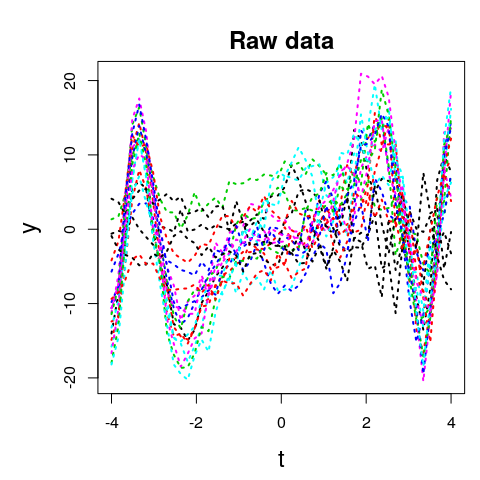

```r
plot(a1, type='raw')
```

To visualise three realisations of the training data:

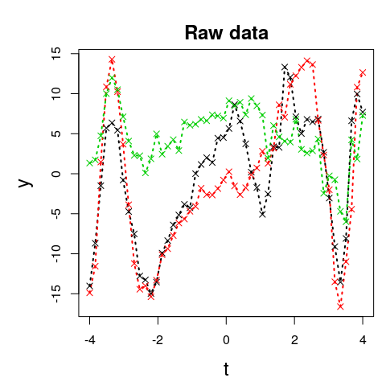

```r
plot(a1, type='raw', realisations = 1:3)
```

### FR fit for training data

The in-sample fit using mean function from FR model only can be seen:

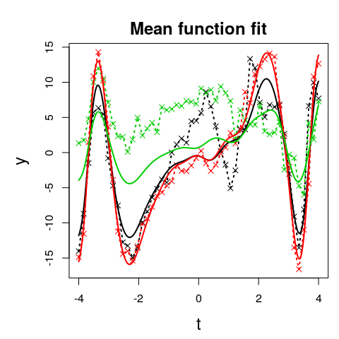

```r
plot(a1, type = 'meanFunction', realisations = 1:3)
```

### GPFR fit for training data

The GPFR model fit to the training data is visualised by using:

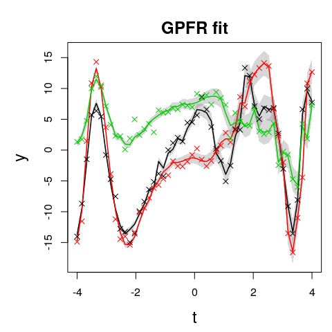

```r
plot(a1, type = 'fitted', realisations = 1:3)
```

### Type I prediction: $y_{M+1}$ observed

If $y_{M+1}(t)$ is observed over all the domain of $t$, the type I prediction can be seen:

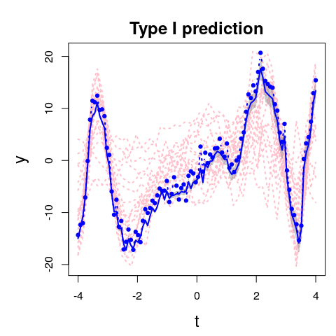

```r
b1 <- gpfrPredict(a1, TestData = as.matrix(x_new), NewTime = t_new,
               lReg = scalar_new, fReg = NULL,
               gpReg = list('response' = response_new,
                            'input' = x_new, 'time' = t_new))

plot(b1, type = 'prediction')
lines(t_new, response_new, type = 'b', col = 4, pch = 19, cex = 0.6, lty = 3, lwd = 2)
```

### Type I prediction: $y_{M+1}$ partially observed

If we assume that $y_{M+1}(t)$ is only partially observed, we can obtain type I predictions via:

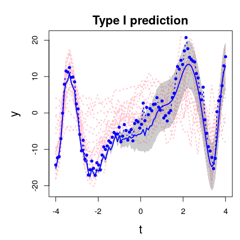

```r
b2 <- gpfrPredict(a1, TestData = as.matrix(x_new), NewTime = t_new,
               lReg = scalar_new, fReg = NULL,
               gpReg = list('response' = response_new[1:20],
                          'input' = x_new[1:20],
                          'time' = t_new[1:20]))

plot(b2, type = 'prediction')
lines(t_new, response_new, type = 'b', col = 4, pch = 19, cex = 0.6, lty = 3, lwd = 2)
```

### Type II prediction: $y_{M+1}$ not observed

Type II prediction, which is made by not including any information about $y_{M+1}(t)$, is visualised below.

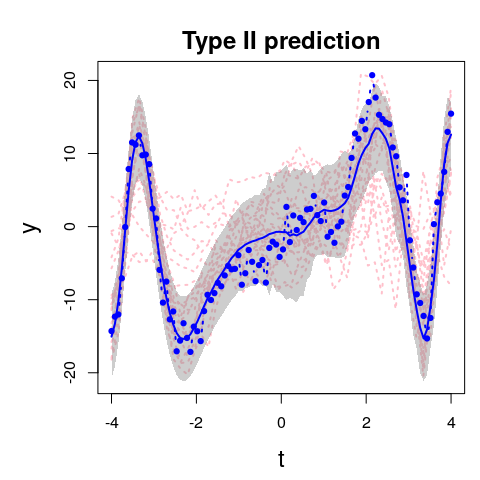

```r
b3 <- gpfrPredict(a1, TestData = as.matrix(x_new), NewTime = t_new,
               lReg = scalar_new, fReg = NULL, gpReg = NULL)

plot(b3, type = 'prediction')
lines(t_new, response_new, type='b', col = 4, pch = 19, cex = 0.6, lty = 3, lwd = 2)
```